# Data624_Optional_Assign

Alexis Mekueko

12/3/2021

[Github Link](https://github.com/asmozo24/Data624_Market_Basket_Analysis)  
[Web Link](https://rpubs.com/amekueko/841685)

Note: This assignment is about how to apply association rule and cluster analysis to market basket analysis.

Association Rule Mining in R Language is an Unsupervised Non-linear algorithm to uncover how the items are associated with each other. In it, frequent Mining shows which items appear together in a transaction or relation. It’s majorly used by retailers, grocery stores, an online marketplace that has a large transactional database. The same way when any online social media, marketplace, and e-commerce websites know what you buy next using recommendations engines. The recommendations you get on item or variable, while you check out the order is because of Association rule mining boarded on past customer data. There are three common ways to measure association:

What Is Market Basket Analysis?

Market Basket Analysis is a technique which identifies the strength of association between pairs of products purchased together and identify patterns of co-occurrence. A co-occurrence is when two or more things take place together.

Market Basket Analysis creates If-Then scenario rules, for example, if item A is purchased then item B is likely to be purchased. The rules are probabilistic in nature or, in other words, they are derived from the frequencies of co-occurrence in the observations. Frequency is the proportion of baskets that contain the items of interest. The rules can be used in pricing strategies, product placement, and various types of cross-selling strategies.

How Market Basket Analysis Works

In order to make it easier to understand, think of Market Basket Analysis in terms of shopping at a supermarket. Market Basket Analysis takes data at transaction level, which lists all items bought by a customer in a single purchase. The technique determines relationships of what products were purchased with which other product(s). These relationships are then used to build profiles containing If-Then rules of the items purchased.

The rules could be written as:

If {A} Then {B} The If part of the rule (the {A} above) is known as the antecedent and the THEN part of the rule is known as the consequent (the {B} above). The antecedent is the condition and the consequent is the result. The association rule has three measures that express the degree of confidence in the rule, Support, Confidence, and Lift.

For example, you are in a supermarket to buy milk. Based on the analysis, are you more likely to buy apples or cheese in the same transaction than somebody who did not buy milk?

Support Support is nothing but a percentage representation. Support = Total number transactions containing Item ’n’ / Total number of transactions

Cluster Analysis

Cluster analysis can be a powerful data-mining tool for any organization that needs to identify discrete groups of customers, sales transactions, or other types of behaviors and things Cluster Analysis in R, when we do data analytics, there are two kinds of approaches one is supervised and another is unsupervised. Clustering is a method for finding subgroups of observations within a data set. When we are doing clustering, we need observations in the same group with similar patterns and observations in different groups to be dissimilar. If there is no response variable, then suitable for an unsupervised method, which implies that it seeks to find relationships between the n observations without being trained by a response variable. Clustering allows us to identify homogenous groups and categorize them from the dataset.

One of the simplest clusterings is K-means, the most commonly used clustering method for splitting a dataset into a set of n groups.

If datasets contain no response variable and with many variables then it comes under an unsupervised approach.

Cluster analysis is an unsupervised approach and sed for segmenting markets into groups of similar customers or patterns. The clustering process itself contains 3 distinctive steps:

1- Calculating dissimilarity matrix — is arguably the most important decision in clustering, and all your further steps are going to be based on the dissimilarity matrix you’ve made. 2- Choosing the clustering method 3- Assessing clusters

## Data Structure

```
## 'data.frame':    9834 obs. of  32 variables:
##  $ citrus.fruit       : chr  "tropical fruit" "whole milk" "pip fruit" "other vegetables" ...
##  $ semi.finished.bread: chr  "yogurt" "" "yogurt" "whole milk" ...
##  $ margarine          : chr  "coffee" "" "cream cheese " "condensed milk" ...
##  $ ready.soups        : chr  "" "" "meat spreads" "long life bakery product" ...
##  $ X                  : chr  "" "" "" "" ...
##  $ X.1                : chr  "" "" "" "" ...
##  $ X.2                : chr  "" "" "" "" ...
##  $ X.3                : chr  "" "" "" "" ...
##  $ X.4                : chr  "" "" "" "" ...
##  $ X.5                : chr  "" "" "" "" ...
##  $ X.6                : chr  "" "" "" "" ...
##  $ X.7                : chr  "" "" "" "" ...
##  $ X.8                : chr  "" "" "" "" ...
##  $ X.9                : chr  "" "" "" "" ...
```

[output cut: 18 more lines]

| citrus.fruit | semi.finished.bread | margarine | ready.soups | X | X.1 | X.2 | X.3 | X.4 | X.5 | X.6 | X.7 | X.8 | X.9 | X.10 | X.11 | X.12 | X.13 | X.14 | X.15 | X.16 | X.17 | X.18 | X.19 | X.20 | X.21 | X.22 | X.23 | X.24 | X.25 | … |
| --- | --- | --- | --- | --- | --- | --- | --- | --- | --- | --- | --- | --- | --- | --- | --- | --- | --- | --- | --- | --- | --- | --- | --- | --- | --- | --- | --- | --- | --- | --- |
| tropical fruit | yogurt | coffee |  |  |  |  |  |  |  |  |  |  |  |  |  |  |  |  |  |  |  |  |  |  |  |  |  |  |  | … |
| whole milk |  |  |  |  |  |  |  |  |  |  |  |  |  |  |  |  |  |  |  |  |  |  |  |  |  |  |  |  |  | … |
| pip fruit | yogurt | cream cheese | meat spreads |  |  |  |  |  |  |  |  |  |  |  |  |  |  |  |  |  |  |  |  |  |  |  |  |  |  | … |
| other vegetables | whole milk | condensed milk | long life bakery product |  |  |  |  |  |  |  |  |  |  |  |  |  |  |  |  |  |  |  |  |  |  |  |  |  |  | … |
| whole milk | butter | yogurt | rice | abrasive cleaner |  |  |  |  |  |  |  |  |  |  |  |  |  |  |  |  |  |  |  |  |  |  |  |  |  | … |
| rolls/buns |  |  |  |  |  |  |  |  |  |  |  |  |  |  |  |  |  |  |  |  |  |  |  |  |  |  |  |  |  | … |
| other vegetables | UHT-milk | rolls/buns | bottled beer | liquor (appetizer) |  |  |  |  |  |  |  |  |  |  |  |  |  |  |  |  |  |  |  |  |  |  |  |  |  | … |
| pot plants |  |  |  |  |  |  |  |  |  |  |  |  |  |  |  |  |  |  |  |  |  |  |  |  |  |  |  |  |  | … |

```
## transactions as itemMatrix in sparse format with
##  9835 rows (elements/itemsets/transactions) and
##  169 columns (items) and a density of 0.02609146
##
## most frequent items:
##       whole milk other vegetables       rolls/buns             soda
##             2513             1903             1809             1715
##           yogurt          (Other)
##             1372            34055
##
## element (itemset/transaction) length distribution:
## sizes
##    1    2    3    4    5    6    7    8    9   10   11   12   13   14   15   16
## 2159 1643 1299 1005  855  645  545  438  350  246  182  117   78   77   55   46
##   17   18   19   20   21   22   23   24   26   27   28   29   32
##   29   14   14    9   11    4    6    1    1    1    1    3    1
##
##    Min. 1st Qu.  Median    Mean 3rd Qu.    Max.
##   1.000   2.000   3.000   4.409   6.000  32.000
##
## includes extended item information - examples:
##             labels
## 1 abrasive cleaner
## 2 artif. sweetener
## 3   baby cosmetics
```

## 2. Data Preparation

### 2.1 Checking for Missing Values

```r
basket1 <- basket

# Filling the empty spece with "NA"
basket1a <- dplyr::na_if(basket1, "")
#dim(basket1a)
#if (is.na(basket) || basket == '')

misValues <- sum(is.na(basket1))# Returning the column names with missing values

#sum(is.na(basket1a$X.1))
#misValues1 <- sum(is.na()
cat("There are missing values for a total record of : " , misValues)
```

```
## There are missing values for a total record of :  0
```

```r
cat("\nThe percentage of the overall missing values in the dataframe is: ", round((sum(is.na(basket1a))/prod(dim(basket1a)))*100, 2))
```

```
##
## The percentage of the overall missing values in the dataframe is:  86.22
```

```r
cat("%")
```

```
## %
```

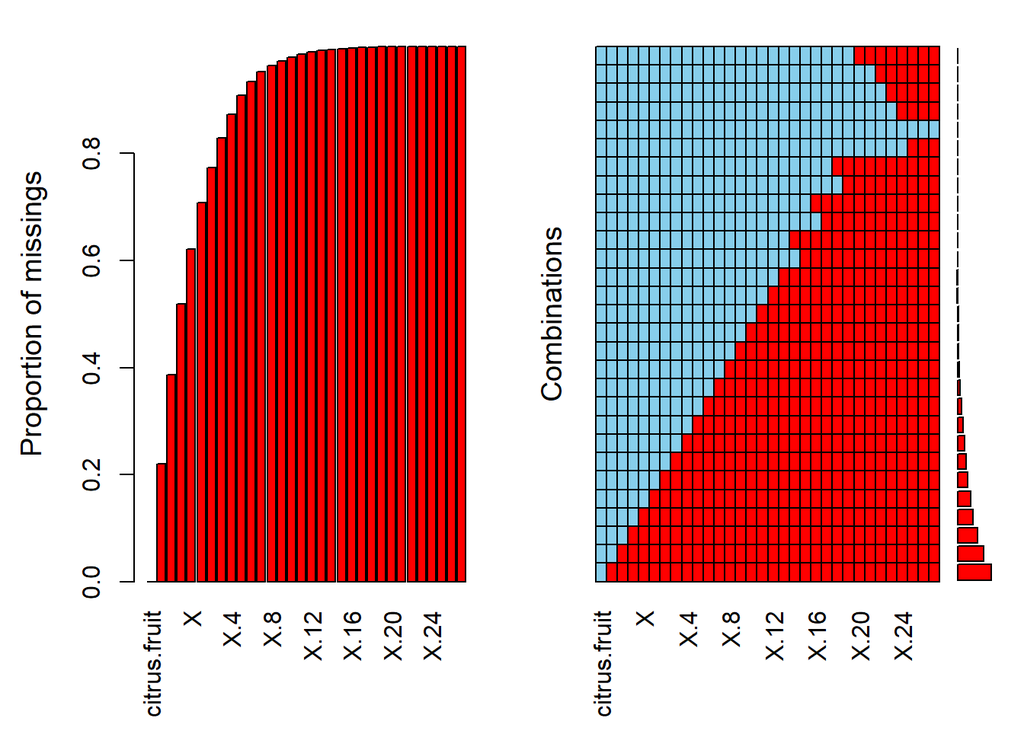

```r
# for visualizing missing values:
#install.packages("VIM")              # Install VIM package
library("VIM")                       # Load VIM
aggr(basket1a)
```

```r
# All below code works fine

#(colMeans(is.na(basket1a)))*100
# apply(basket1a, 2, function(col)sum(is.na(col))/length(col))
#
# basket1a %>%
#   summarize_all(funs(sum(is.na(.)) / length(.)))
# basket1a%>%
#   summarise_all(list(name = ~sum(is.na(.))/length(.)))
# sapply(basket1a, function(y) round((sum(length(which(is.na(y))))/nrow(basket1a))*100.00,2))
# apply(is.na(basket1a), 2, sum)
# column_na1 <- colnames(basket1a)[ apply(basket1a, 2, anyNA) ] # 2 is dimension(dim())



missing.values <- function(df){
    df %>%
    gather(key = "variables", value = "val") %>%
    mutate(is.missing = is.na(val)) %>%
    group_by(variables, is.missing) %>%
    dplyr::summarise(number.missing = n()) %>%
    filter(is.missing==T) %>%
    dplyr::select(-is.missing) %>%
    arrange(desc(number.missing))
}

missing.values(basket1a)%>%
  kable()
```

| variables | number.missing |
| --- | --- |
| X.25 | 9833 |
| X.26 | 9833 |
| X.27 | 9833 |
| X.24 | 9830 |
| X.23 | 9829 |
| X.22 | 9828 |
| X.20 | 9827 |
| X.21 | 9827 |
| X.19 | 9826 |
| X.18 | 9820 |
| X.17 | 9816 |
| X.16 | 9805 |
| X.15 | 9796 |
| X.14 | 9782 |
| X.13 | 9768 |
| X.12 | 9739 |
| X.11 | 9693 |
| X.10 | 9638 |
| X.9 | 9561 |
| X.8 | 9483 |
| X.7 | 9366 |
| X.6 | 9184 |
| X.5 | 8938 |
| X.4 | 8588 |
| X.3 | 8150 |
| X.2 | 7605 |
| X.1 | 6960 |
| X | 6105 |
| ready.soups | 5101 |
| margarine | 3802 |
| semi.finished.bread | 2159 |

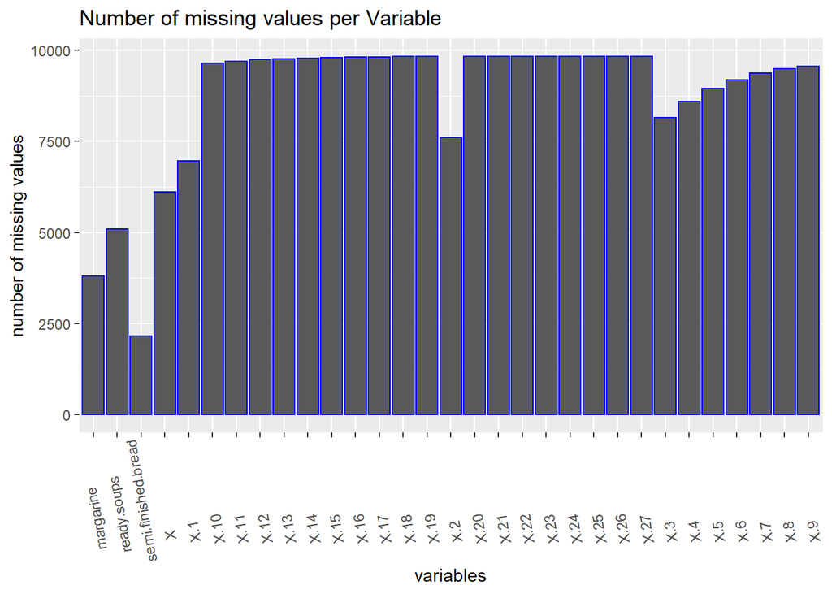

```r
# plot missing values
 missing.values(basket1a) %>%
   ggplot() +
     geom_bar(aes(x=variables, y=number.missing), stat = 'identity', col='blue') +
     labs(x='variables', y="number of missing values", title='Number of missing values per Variable') +
   theme(axis.text.x = element_text(angle = 100, hjust = 0.2))
```

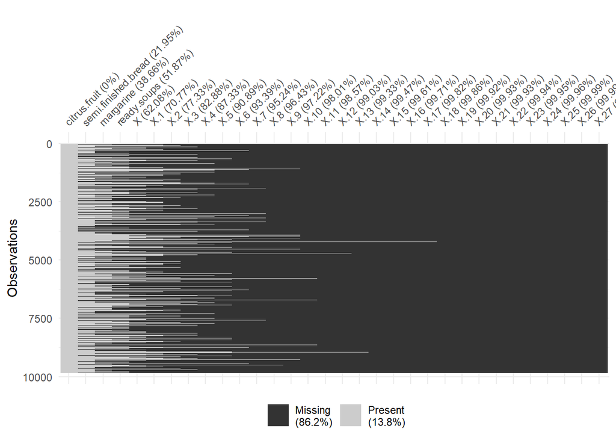

```r
# Let's see percentage of missing values per column in proportion to number total record (total rows)
vis_miss(basket1a)
```

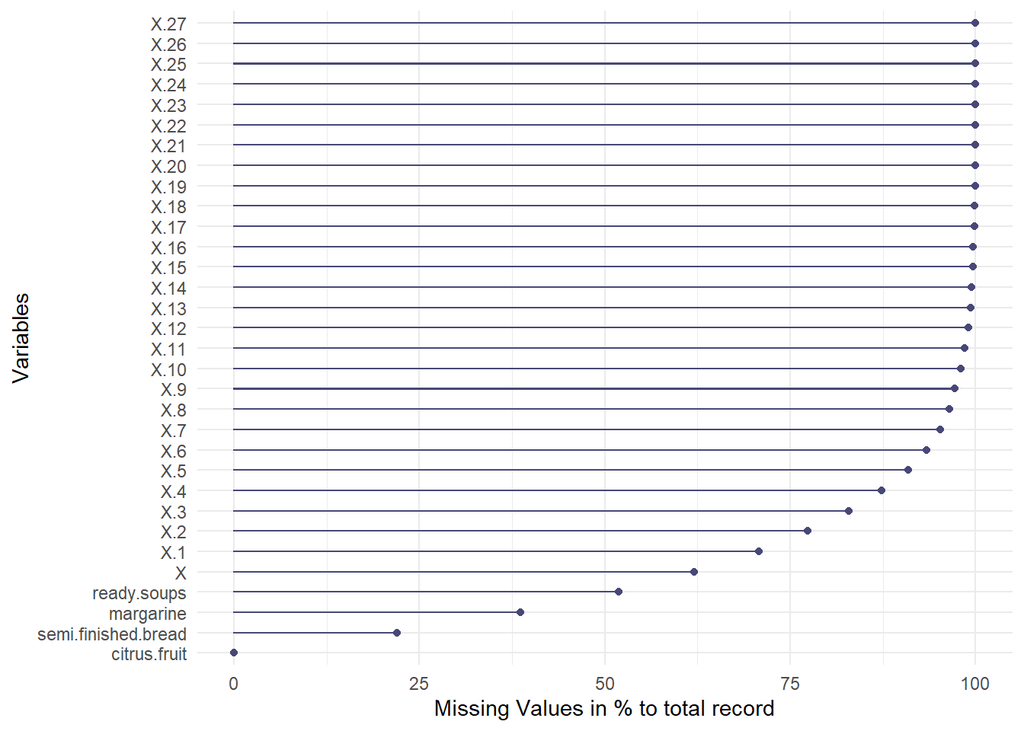

```r
gg_miss_var(basket1a, show_pct = TRUE) + labs(y = "Missing Values in % to total record")+ theme()
```

```r
#colSums(is.na(df))%>% kable()
cat("\n The table below shows the total number of missing values per variable")
```

[output not shown]

```
##
##  The table below shows the total number of missing values per variable
```

```r
#df1 <- drop_na(df)
```

#### Dealing with Missing values

We found that the dataset has a lot of missing values. To handle this issue, our approach is to remove all variables with more than 80% missing variables.

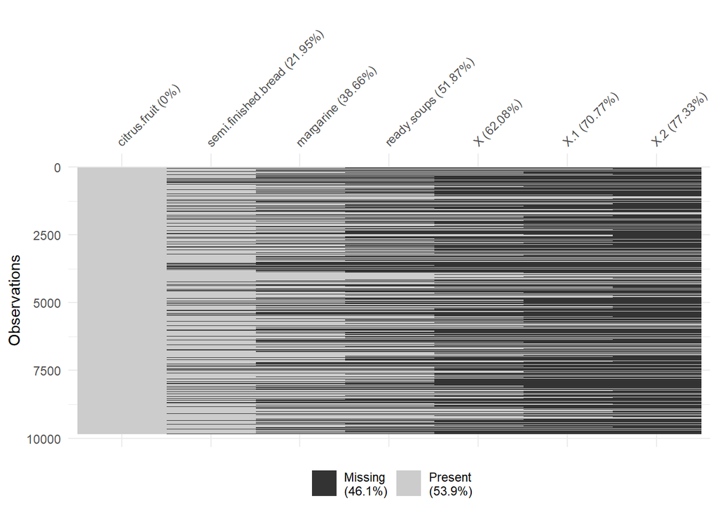

```
## Apriori
##
## Parameter specification:
##  confidence minval smax arem  aval originalSupport maxtime support minlen
##         0.2    0.1    1 none FALSE            TRUE       5   0.004      1
##  maxlen target  ext
##      10  rules TRUE
##
## Algorithmic control:
##  filter tree heap memopt load sort verbose
##     0.1 TRUE TRUE  FALSE TRUE    2    TRUE
##
## Absolute minimum support count: 39
##
## set item appearances ...[0 item(s)] done [0.00s].
## set transactions ...[169 item(s), 9835 transaction(s)] done [0.00s].
## sorting and recoding items ... [126 item(s)] done [0.00s].
## creating transaction tree ... done [0.00s].
## checking subsets of size 1 2 3 4 5 done [0.00s].
## writing ... [1268 rule(s)] done [0.00s].
## creating S4 object  ... done [0.00s].
```

The model minimum length is 1, the maximum length is 10, and the target rules with absolute support count is 39. There are 1268 rules for this market analysis. 1268 rules is a lot and can be difficult to focus on. One thing that might affect this number of rules is missing values. The dataset contains a lot of missing value. The result would be different if no value were missing. That being said, we are not confident in applying imputation technique here as it can throw a bias in the analysis and caused misleading information to the decision maker. For this analysis, we will focus on top items (20)

###Let’s plot the top 20 items in the basket

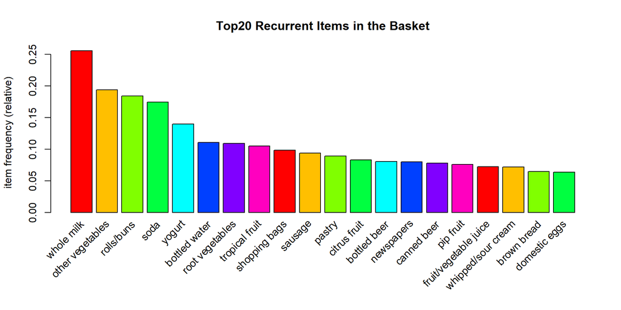

From the top20 item in the basket plot, we see that item = whole milk sells the most. The next items are “other vegetables”, “rolls/buns” and non-alcoholic drinks. If I am the manager of the store, I would position the shelves of these top 8 items(looks similar) by the cashiers or close to the entries. This way, customers can get what they want easily and quick. Happy customer are always willing to buy additional items if they already purchased their top items in the list in a short manner of time.

```
##      lhs                      rhs                      support confidence    coverage     lift count
## [1]  {flour}               => {sugar}              0.004982206  0.2865497 0.017386884 8.463112    49
## [2]  {processed cheese}    => {white bread}        0.004168785  0.2515337 0.016573462 5.975445    41
## [3]  {liquor}              => {bottled beer}       0.004677173  0.4220183 0.011082867 5.240594    46
## [4]  {berries,
##       whole milk}          => {whipped/sour cream} 0.004270463  0.3620690 0.011794611 5.050990    42
## [5]  {herbs,
##       whole milk}          => {root vegetables}    0.004168785  0.5394737 0.007727504 4.949369    41
## [6]  {citrus fruit,
##       other vegetables,
##       tropical fruit}      => {root vegetables}    0.004473818  0.4943820 0.009049314 4.535678    44
## [7]  {other vegetables,
##       root vegetables,
##       tropical fruit}      => {citrus fruit}       0.004473818  0.3636364 0.012302999 4.393567    44
## [8]  {whipped/sour cream,
##       yogurt}              => {curd}               0.004575496  0.2205882 0.020742247 4.140239    45
## [9]  {citrus fruit,
##       other vegetables,
##       root vegetables}     => {tropical fruit}     0.004473818  0.4313725 0.010371124 4.110997    44
## [10] {citrus fruit,
##       other vegetables,
##       whole milk}          => {root vegetables}    0.005795628  0.4453125 0.013014743 4.085493    57
```

In data mining and association rule learning, lift is a measure of the performance of a targeting model (association rule) at predicting or classifying cases as having an enhanced response (with respect to the population as a whole), measured against a random choice targeting model.

the lift or lift ratio is the ratio of confidence to expected confidence. Expected confidence is the confidence divided by the frequency of B. The Lift tells us how much better a rule is at predicting the result than just assuming the result in the first place. Greater lift values indicate stronger associations.

By lift measure, we see that these items a relative strong association together.

In other words, the probability of buying sugar with the knowledge that flour is already present in the basket is much higher than the probability of buying sugar without the knowledge about the presence of flour.

the probability of buying white bread with the knowledge that processed cheese is already present in the basket is much higher than the probability of buying white bread without the knowledge about the presence of processed cheese.

The presence of flour in the basket increases the probability of buying sugar.

The same formula goes for the remaining 03 association…

This would have been the other way around if the value of lift associated with item were less than 1. In this case, we would say that…the probability of buying B with the knowledge that A is already present in the basket is much lower than the probability of buying B without the knowledge about the presence of A. The presence of A in the basket does not increases the probability of buying B.

```
##      lhs                      rhs                    support confidence    coverage     lift count
## [1]  {citrus fruit,
##       root vegetables,
##       tropical fruit}      => {other vegetables} 0.004473818  0.7857143 0.005693950 4.060694    44
## [2]  {curd,
##       domestic eggs}       => {whole milk}       0.004778851  0.7343750 0.006507372 2.874086    47
## [3]  {butter,
##       curd}                => {whole milk}       0.004880529  0.7164179 0.006812405 2.803808    48
## [4]  {tropical fruit,
##       whipped/sour cream,
##       yogurt}              => {whole milk}       0.004372140  0.7049180 0.006202339 2.758802    43
## [5]  {root vegetables,
##       tropical fruit,
##       yogurt}              => {whole milk}       0.005693950  0.7000000 0.008134215 2.739554    56
## [6]  {butter,
##       other vegetables,
##       yogurt}              => {whole milk}       0.004372140  0.6825397 0.006405694 2.671221    43
## [7]  {other vegetables,
##       pip fruit,
##       root vegetables}     => {whole milk}       0.005490595  0.6750000 0.008134215 2.641713    54
## [8]  {butter,
##       whipped/sour cream}  => {whole milk}       0.006710727  0.6600000 0.010167768 2.583008    66
## [9]  {hard cheese,
##       yogurt}              => {whole milk}       0.004168785  0.6507937 0.006405694 2.546978    41
## [10] {pip fruit,
##       whipped/sour cream}  => {whole milk}       0.005998983  0.6483516 0.009252669 2.537421    59
```

The confidence of an association rule is a percentage value that shows how frequently the rule head occurs among all the groups containing the rule body. The confidence value indicates how reliable this rule is. The higher the value, the more likely the head items occur in a group if it is known that all body items are contained in that group…. You set minimum confidence as part of defining mining settings.

the confidence of the rule is the ratio of the number of transactions that include all items in {B} as well as the number of transactions that include all items in {A} to the number of transactions that include all items in {A}.

The association rule by confident shows relations between: 1 - {citrus fruit, root vegetables, tropical fruit} and {other vegetables} = 0.7857143 or 78.57% 2- {curd, domestic eggs} and {whole milk} = 0.7343750 or 73.44% 3- {butter, curd} and {whole milk} = 0.7164179 or 71.64% 4- {tropical fruit, whipped/sour cream, yogurt} and {whole milk} = 0.7049180 or 70.49% 5- {root vegetables, tropical fruit, yogurt} and {whole milk} = 0.7000000 or 70%

By confidence measure, we see that item “whole milk” dominate the top 10 of the items that customers buy in association with other item in the store. This means whole milk must be present in sufficient quantity in other for other items in the top 10 to sell. Frustrated customers are the those that cannot find what they usually buy when to certain store. This can have a negative effect on the customers shopping. In fact, it might result in customers leaving the store and attempting to find it at another retailer.

Interpretation:

There is a 78.57% chance that a customer will buy {other vegetables} if customer has already bought {citrus fruit, root vegetables, tropical fruit} There is a 73.44% chance that a customer will buy {whole milk} if customer has already bought {curd, domestic eggs}

The same formula goes for the remaining 03 association rules.

Let’s see the plot

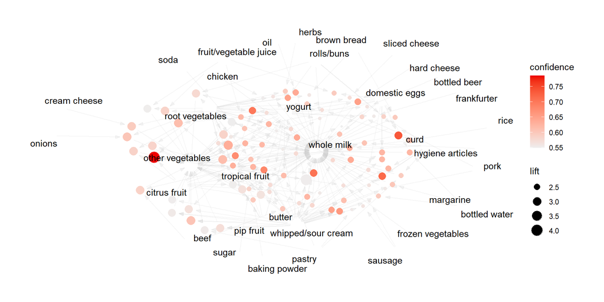

Let’s visualize the top 10 association rules.

[interactive chart not shown]

Cluster Analysis

Gower’s Distance Metric For categorical data or generally for mixed data types (numerical and categorical data types), we use Hierarchical Clustering. In this method, we need a function to calculate the distance between observations of data. A useful metric named Gower is used as a parameter of function daisy() in R package, cluster. This metric calculates the distance between categorical, or mixed, data types. In daisy function, we can weigh features by parameter weights.

Unsupervised learning techniques generally require that the data be appropriately scaled. Gower is a scaling algorithm applied to mixed numeric and categorical data to bring all variables to a 0–1 range[1]

Something not going right with the data. We think the missing values need to be taking care first.

###References

https://www.geeksforgeeks.org/association-rule-mining-in-r-programming/

https://www.r-bloggers.com/2021/04/cluster-analysis-in-r/

https://medium.com/@maryam.alizadeh/clustering-categorical-or-mixed-data-in-r-c0fb6ff38859

https://www.ibm.com/docs/en/db2/9.7?topic=associations-confidence-in-association-rule

https://infocenter.informationbuilders.com/wf80/index.jsp?topic=%2Fpubdocs%2FRStat16%2Fsource%2Ftopic49.htm

https://sanjayjsw05.medium.com/why-lift-has-bigger-role-than-confidence-in-association-rules-619324fc21ab

https://towardsdatascience.com/hierarchical-clustering-on-categorical-data-in-r-a27e578f2995